# Heart Failure Prediction Dataset

## PairGrid and Correlation

```python
df_corr = df[['Age', 'Sex', 'RestingBP', 'Cholesterol', 'FastingBS', 'MaxHR', 'Oldpeak', 'ExerciseAngina', 'HeartDisease']].copy()
```

```python
df_corr['Sex'] = df_corr['Sex'].map({'M':0, 'F':1}).astype(int)
df_corr['ExerciseAngina'] = df_corr['ExerciseAngina'].map({'N':0, 'Y':1}).astype(int)
```

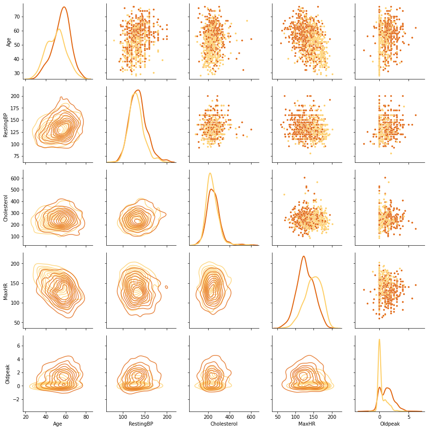

```python
g = sns.PairGrid(df[['Age', 'RestingBP', 'Cholesterol', 'MaxHR', 'Oldpeak', 'HeartDisease']], hue = 'HeartDisease', diag_sharey = False, palette = pal)
g.map_upper(sns.scatterplot, s = 15)
g.map_lower(sns.kdeplot, fill = False, alpha = .8)
g.map_diag(sns.kdeplot, lw = 2)
plt.show()
```

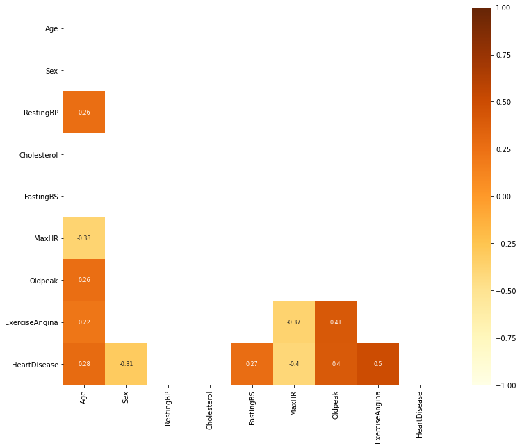

```python
t = 0.2
corr = df_corr.corr()

matrix = np.triu(corr)
plt.figure(figsize = (16, 10))

sns.heatmap(corr[(corr >= t) | (corr <= -t)], mask = matrix, cmap = pal, vmax = 1.0, vmin = -1.0, annot = True, annot_kws = {"size": 8}, square = True);
```

**Zobrazeny jsou pouze korelace nad hodnotou 0,2 bez horní poloviny a diagonály.*

- 0.2 - 0.4 - Weak correlation
- 0.4 - 0.6 - Moderate correlation
- 0.6 - 0.8 - Strong correlation

**Pozorování**

## EDA summary

- Muži a starší lidé jsou náchylnější na srdeční nemoci.
- Nejčastější bolestí u pacientů je bolest typu ASY, která má zároveň největší pravděpodobnost na spojení se srdeční nemocí (téměř 80%).
- Jako sloupec s největší prediktivní silou se zdá být sloupec ST_Slope
- Oldpeak je jediný numerický sloupec, který nemá normální rozdělení.
- Dataset neobsahuje vysoce multikolineární sloupce.
- Sloupec cholesterol obsahuje 18.6% chybějících záznamů.

# Clustering Analysis

## Data preprocessing

```python
df_prep = df.copy()
df_prep.head(2)
```

|  | Age | Sex | ChestPainType | RestingBP | Cholesterol | FastingBS | RestingECG | MaxHR | ExerciseAngina | Oldpeak | ST_Slope | HeartDisease |
| --- | --- | --- | --- | --- | --- | --- | --- | --- | --- | --- | --- | --- |
| 0 | 40 | M | ATA | 140 | 289.0 | 0 | Normal | 172 | N | 0.0 | Up | 0 |
| 1 | 49 | F | NAP | 160 | 180.0 | 0 | Normal | 156 | N | 1.0 | Flat | 1 |

#### Binary features and ordinal text features -> ordered numbers

```python
df_prep['Sex'] = df_prep['Sex'].map({'M':0, 'F':1}).astype(int)
df_prep['ExerciseAngina'] = df_prep['ExerciseAngina'].map({'Y':0, 'N':1}).astype(int)
```

#### Categorical features -> one-hot encoding

```python
df_prep = pd.get_dummies(df_prep, columns = ['ChestPainType', 'RestingECG', 'ST_Slope'])
```

#### Filling missing values for Cholesterol

```
count    746.000000
mean     244.635389
std       59.153524
min       85.000000
25%      207.250000
50%      237.000000
75%      275.000000
max      603.000000
Name: Cholesterol, dtype: float64
```

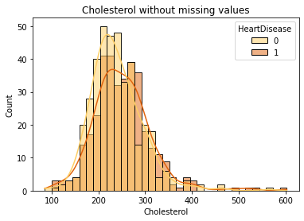

```python
print(df_prep.Cholesterol.describe())

sns.histplot(data = df_prep, hue = 'HeartDisease', x = 'Cholesterol', kde = True, palette = pal).set_title('Cholesterol without missing values')
plt.show()
```

Groupby method

```python
Cholesterol_groupby = df_prep['Cholesterol'].fillna(df.groupby(['Sex', 'ST_Slope', 'ExerciseAngina'])['Cholesterol'].transform('mean'))
```

```
count    917.000000
mean     244.551913
std       53.465513
min       85.000000
25%      214.000000
50%      243.000000
75%      267.000000
max      603.000000
Name: Cholesterol, dtype: float64
```

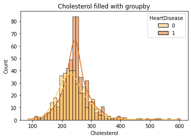

```python
print(Cholesterol_groupby.describe())

sns.histplot(data = df_prep, hue = 'HeartDisease', x = Cholesterol_groupby, kde = True, palette = pal).set_title('Cholesterol filled with groupby')
plt.show()
```

KNN imputer

```python
imputer = KNNImputer(n_neighbors = 5)
df_prep[df_prep.columns] = imputer.fit_transform(df_prep[df_prep.columns])
```

```
count    917.000000
mean     244.967721
std       54.674832
min       85.000000
25%      212.000000
50%      239.200000
75%      273.000000
max      603.000000
Name: Cholesterol, dtype: float64
```

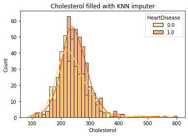

```python
print(df_prep.Cholesterol.describe())

sns.histplot(data = df_prep, hue = 'HeartDisease', x = 'Cholesterol', kde = True, palette = pal).set_title('Cholesterol filled with KNN imputer')
plt.show()
```

Doplnění chybějících hodnot pomocí metody KNN Imputer je blíže distribuci bez chybějíchích hodnot, takže zvolím tento způsob doplnění chybějíchích hodnot.

```python
df_prep.head(2)
```

|  | Age | Sex | RestingBP | Cholesterol | FastingBS | MaxHR | ExerciseAngina | Oldpeak | HeartDisease | ChestPainType_ASY | ChestPainType_ATA | ChestPainType_NAP | ChestPainType_TA | RestingECG_LVH | RestingECG_Normal | RestingECG_ST | ST_Slope_Down | ST_Slope_Flat | ST_Slope_Up |
| --- | --- | --- | --- | --- | --- | --- | --- | --- | --- | --- | --- | --- | --- | --- | --- | --- | --- | --- | --- |
| 0 | 40.0 | 0.0 | 140.0 | 289.0 | 0.0 | 172.0 | 1.0 | 0.0 | 0.0 | 0.0 | 1.0 | 0.0 | 0.0 | 0.0 | 1.0 | 0.0 | 0.0 | 0.0 | 1.0 |
| 1 | 49.0 | 1.0 | 160.0 | 180.0 | 0.0 | 156.0 | 1.0 | 1.0 | 1.0 | 0.0 | 0.0 | 1.0 | 0.0 | 0.0 | 1.0 | 0.0 | 0.0 | 1.0 | 0.0 |

#### Scaling all features to 0-1 range

```python
scaler = MinMaxScaler()
scaled_data = scaler.fit_transform(df_prep.drop(['HeartDisease'], axis=1))
```

```python
scaled_data[0]
```

```
array([0.24489796, 0.        , 0.5       , 0.39382239, 0.        ,
       0.78873239, 1.        , 0.29545455, 0.        , 1.        ,
       0.        , 0.        , 0.        , 1.        , 0.        ,
       0.        , 0.        , 1.        ])
```